# M280 Homework 2

- Author: Shuang Gao
- Date: 2018/05/02

## Question 1

1.1 Implement the algorithm with arguments: $X$ (data, each row is a vectorized image), rank $r$ , convergence tolerance, and optional starting point.

```julia
function nnmf(
 X::Matrix{T},
 r::Int;
 maxiter::Int = 1000,
 tol::T = 1e-4,
 V::Matrix{T} = rand(T, size(X, 1), r),
 W::Matrix{T} = rand(T, r, size(X, 2))
 )  where T <: AbstractFloat

    # store V*W
    mul_VW = zeros(size(X))

    # initialize the denomenator and numerator for V update
    denomenator_V = zeros(size(V))
    numerator_V = zeros(size(V))

    # initialize the denomenator and numerator for W update
    denomenator_W = zeros(size(W))
    numerator_W = zeros(size(W))

    # initialize the matrix to store r by r matrix
    out_rr = zeros(r, r)

    # store the initial norm L
    L = sum(abs2, X - A_mul_B!(mul_VW, V, W))

    for t in 1:maxiter # stop after 1000 iterations
        # update v
        # denomenator_V = V * W * W'
        # numerator_V = X * W'
        V .= V .* (A_mul_Bt!(numerator_V, X, W) ./
            A_mul_B!(denomenator_V, V, A_mul_Bt!(out_rr, W, W)))

        # update W
        # denomenator_W = V' * V * W
        # numerator_W = V' * X

        # update W
        W .= W .* At_mul_B!(numerator_W, V, X) ./
        A_mul_B!(denomenator_W, At_mul_B!(out_rr, V, V), W)

        # check norm difference
        if abs(sum(abs2, X - A_mul_B!(mul_VW, V, W)) - L) / (L + 1) < tol
            # store norm and quit the loop
            L = sum(abs2, X - A_mul_B!(mul_VW, V, W))
            break
        end

        # update norm
        L = sum(abs2, X - A_mul_B!(mul_VW, V, W))

    end

    # Output
    return L, V, W
end
```

```
nnmf (generic function with 1 method)
```

1.2 Database 1 from the MIT Center for Biological and Computational Learning (CBCL) reduces to a matrix $X$ containing $m=2,429$ gray-scale face images with $n=19×19=361$ pixels per face. Each image (row) is scaled to have mean and standard deviation 0.25. Read in the nnmf-2429-by-361-face.txt file, e.g., using readdlm() function, and display a couple sample images, e.g., using ImageView.jl package.

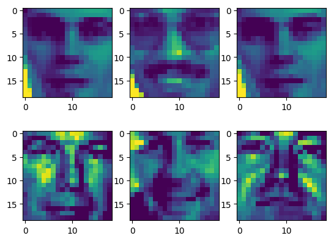

```
PyObject <matplotlib.image.AxesImage object at 0x000000002813D3C8>
```

```julia
# add package for visulizating image
#Pkg.add("ImageView")
#Pkg.add("Images")
#Pkg.add("TestImages")
#Pkg.build("Cairo")
#Pkg.pin("Cairo", v"0.4.0")
#Pkg.update()
#Pkg.add("PyPlot")
using ImageView, Images, PyPlot

# readin matrix file
path_X_1 = "http://Hua-Zhou.github.io/teaching/biostatm280-2018spring/"
path_X_2 = "hw/hw2/nnmf-2429-by-361-face.txt"
X = readdlm(download(path_X_1*path_X_2), ' ')

# randomly show six face images
# extract one row pixels to form one face image
img1 = reshape(X[10, :], 19, 19)
img2 = reshape(X[20, :], 19, 19)
img3 = reshape(X[9, :], 19, 19)
img4 = reshape(X[75, :], 19, 19)
img5 = reshape(X[321, :], 19, 19)
img6 = reshape(X[99, :], 19, 19)

# allgn multiple plots
subplot(231)
PyPlot.imshow(img1)

subplot(232)
PyPlot.imshow(img2)

subplot(233)
PyPlot.imshow(img3)

subplot(234)
PyPlot.imshow(img4)

subplot(235)
PyPlot.imshow(img5)

subplot(236)
PyPlot.imshow(img6)
```

1.3 Report the run times, using `@time`, of your function for fitting NNMF on the MIT CBCL face data set at ranks $r=10, 20, 30, 40, 50$. For ease of comparison (and grading), please start your algorithm with the provided $\mathbf{V}^{(0)}$ (first $r$ columns of [`V0.txt`](http://hua-zhou.github.io/teaching/biostatm280-2018spring/hw/hw2/V0.txt)) and $\mathbf{W}^{(0)}$ (first $r$ rows of [`W0.txt`](http://hua-zhou.github.io/teaching/biostatm280-2018spring/hw/hw2/W0.txt)) and stopping criterion $$ \frac{|L^{(t+1)} - L^{(t)}|}{|L^{(t)}| + 1} \le 10^{-4}. $$

- **Because the first time running code will include compile time, in the results below, all the functions ran twice with `@time`.**

```julia
# readin matrix V0
path_V0_1 = "http://Hua-Zhou.github.io/teaching/biostatm280-"
path_V0_2 = "2018spring/hw/hw2/V0.txt"

V0 = readdlm(download(path_V0_1*path_V0_2), ' ')

# readin matrix W0
path_W0_1 = "http://Hua-Zhou.github.io/teaching/biostatm280-"
path_W0_2 = "2018spring/hw/hw2/W0.txt"

W0 = readdlm(download(path_W0_1*path_W0_2), ' ')

# readin matrix file
path_X_1 = "http://Hua-Zhou.github.io/teaching/biostatm280-2018spring/"
path_X_2 = "hw/hw2/nnmf-2429-by-361-face.txt"

X = readdlm(download(path_X_1*path_X_2), ' ');
```

- when Rank = 10

```julia
# when r = 10
V = V0[:, 1:10]
W = W0[1:10, :]

#@time nnmf(X, 10, maxiter = 1000, tol = 1e-4, V = V0, W = W0)
@time L1, V1, W1 = nnmf(X, 10, maxiter = 1000, tol = 1e-4, V = V, W = W);
@time L1, V1, W1 = nnmf(X, 10, maxiter = 1000, tol = 1e-4, V = V, W = W);
```

```
  4.908382 seconds (982 allocations: 3.136 GiB, 12.54% gc time)
  0.077358 seconds (30 allocations: 27.188 MiB, 10.09% gc time)
```

- when Rank = 20

```julia
# when r = 20
V = V0[:, 1:20]
W = W0[1:20, :]

@time L2, V2, W2 = nnmf(X, 20, maxiter = 1000, tol = 1e-4, V = V, W = W);
@time L2, V2, W2 = nnmf(X, 20, maxiter = 1000, tol = 1e-4, V = V, W = W);
```

```
  8.483413 seconds (1.60 k allocations: 5.162 GiB, 9.85% gc time)
  0.062667 seconds (30 allocations: 27.616 MiB, 22.46% gc time)
```

- when Rank = 30

```julia
# when r = 30
V = V0[:, 1:30]
W = W0[1:30, :]

@time L3, V3, W3 = nnmf(X, 30, maxiter = 1000, tol = 1e-4, V = V, W = W);
@time L3, V3, W3 = nnmf(X, 30, maxiter = 1000, tol = 1e-4, V = V, W = W);
```

[output not shown]

```
 12.410618 seconds (1.96 k allocations: 6.312 GiB, 7.84% gc time)
  0.038009 seconds (30 allocations: 28.045 MiB, 10.60% gc time)
```

[output not shown]

- when Rank = 40

```julia
# when r = 40
V = V0[:, 1:40]
W = W0[1:40, :]

@time L4, V4, W4 = nnmf(X, 40, maxiter = 1000, tol = 1e-4, V = V, W = W);
@time L4, V4, W4 = nnmf(X, 40, maxiter = 1000, tol = 1e-4, V = V, W = W);
```

[output not shown]

```
 16.921407 seconds (2.35 k allocations: 7.606 GiB, 6.64% gc time)
  0.040456 seconds (30 allocations: 28.476 MiB, 10.10% gc time)
```

[output not shown]

- When Rank = 50

```julia
# when r = 50
V = V0[:, 1:50]
W = W0[1:50, :]

@time L5, V5, W5 = nnmf(X, 50, maxiter = 1000, tol = 1e-4, V = V, W = W);
@time L5, V5, W5 = nnmf(X, 50, maxiter = 1000, tol = 1e-4, V = V, W = W);
```

```
 22.567471 seconds (2.82 k allocations: 9.136 GiB, 6.79% gc time)
  0.070430 seconds (31 allocations: 28.909 MiB, 13.66% gc time)
```

1.4 Choose an $r∈{10,20,30,40,50}$ and start your algorithm from a different $V(0)$ and $W(0)$ . Do you obtain the same objective value and $(V,W)$ ? Explain what you find.

- **Choose $r = 10$**

```julia
V = V0[:, 40:49]
W = W0[41:50, :]

L6, V6, W6 = nnmf(X, 10, maxiter = 1000, tol = 1e-4, V = V, W = W);

# compare norm
display(L6)
display(L1)

# compare (V, W) set
display(sqrt(sum(abs2, V1*W1 - V6*W6)))

# compare V1 and V6
display(sqrt(sum(abs2, V1 - V6)))

# compare W1 and W6
display(sqrt(sum(abs2, W1 - W6)))
```

```
11610.785163588704
```

```
11729.228557363946
```

```
44.19009954357648
```

```
10.960218593674151
```

```
60.64420821390958
```

- I randomly choose 10 columns in $V0$ and 10 rows in $W0$ to get norm $L6$, approximating matrices set $(V6, W6)$, instead of using first 10 rows in $V0$ and first 10 rows in $W0$ to get norm $L1$, approximating matrices set $(V1, W1)$. After applying the `nnmf()` to the two set of starting point matrices, the Frobenius norm difference is less than 200. The Frobenius norm of the $(V, W)$ set difference (shown as the difference of the $V*W$ to compare the difference of the approximated original matrix $X$)is around 44. The Frobenius norm difference between $V1$ and $V6$ is around 10 and the Frobenius norm difference between $W1$ and $W6$ is around 60.
- Considering the large size of the matrix, all the difference mentioned are moderate. The set of $(V, W)$ is calculated to approximate matrix $X$. Since both $(V6, W6)$ and $(V1, W1)$ are used to approximate the same matrix, the Frobenius norm difference should be close for these two set.
- From different starting points, different solution $(V, W)$ returns. This indicates the solution of approximating $X$ by two product is not unique. However, the different solutions are close to each other. The small difference on Frobenius norm indicates, although the iterative method to approximate $X$ depends on the starting point, `nnmf()` is very robust to return similar solutions.

1.5 For the same $r$ , start your algorithm from $v(0)_{ik}=w(0)_{kj}=1$ for all $i,j,k$ . Do you obtain the same objective value and $(V,W)$ ? Explain what you find.

```julia
# set matrices with elements 1
V = ones(2429, 10)
W = ones(10, 361)

L7, V7, W7 = nnmf(X, 10, maxiter = 1000, tol = 1e-4, V = V, W = W);

# compare norm
display(L7)
display(L1)

# compare (V, W) set
display(sqrt(sum(abs2, V1*W1 - V7*W7)))

# compare V1 and V7
display(sqrt(sum(abs2, V1 - V7)))

# compare W1 and W7
display(sqrt(sum(abs2, W1 - W7)))
```

```
25297.016511081845
```

```
11729.228557363946
```

```
108.46176768891634
```

```
8.641657001427083
```

```
52.754838138632394
```

1.6 Plot the basis images (rows of $W$ ) at rank $r=50$ . What do you find?

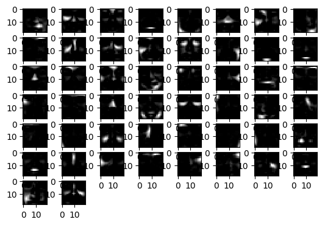

```julia
for i in 1:50
    subplot(8,8,i)
    # extract one row pixels in Wto form one face image
    img = reshape(W5[i, :], 19, 19)
    PyPlot.imshow(img, cmap = "gray")
end
```

- The images of the rows in W(rank = 50)shows the parts of the faces.

### Question 2 Linear Mixed Models

Consider a linear mixed effects model $$ y_i = \mathbf{x}_i^T \beta + \mathbf{z}_i^T \gamma + \epsilon_i, \quad i=1,\ldots,n, $$ where $\epsilon_i$ are independent normal errors $N(0,\sigma_0^2)$, $\beta \in \mathbb{R}^p$ are fixed effects, and $\gamma \in \mathbb{R}^q$ are random effects assumed to be $N(\mathbf{0}_q, \sigma_1^2 \mathbf{I}_q$) independent of $\epsilon_i$.

2.1 Show that $$ \mathbf{y} \sim N \left( \mathbf{X} \beta, \sigma_0^2 \mathbf{I}_n + \sigma_1^2 \mathbf{Z} \mathbf{Z}^T \right), $$ where $\mathbf{y} = (y_1, \ldots, y_n)^T \in \mathbb{R}^n$, $\mathbf{X} = (\mathbf{x}_1, \ldots, \mathbf{x}_n)^T \in \mathbb{R}^{n \times p}$, and $\mathbf{Z} = (\mathbf{z}_1, \ldots, \mathbf{z}_n)^T \in \mathbb{R}^{n \times q}$.

$$ \begin{align} \because \mathbf{y} = \mathbf{X} \beta + \mathbf{Z} \gamma + \epsilon \\ \mathbf{\epsilon} \sim N(\mathbf{0}_n,\sigma_0^2 \mathbf{I}_n) \\ \gamma \sim N(\mathbf{0}_q, \sigma_1^2 \mathbf{I}_q) \\ \epsilon \perp \gamma \\ \end{align} $$

$$ \begin{align} \therefore E(\mathbf{y}) &= E(\mathbf{X} \beta + \mathbf{Z} \gamma + \mathbf{\epsilon})\\ &= E(\mathbf{X} \beta) + E(\mathbf{Z} \gamma) + E(\mathbf{\epsilon}) \\ &= \mathbf{X} \beta + \mathbf{Z} E(\gamma) + \mathbf{0} \\ &= \mathbf{X} \beta + \mathbf{0} + \mathbf{0} \\ &= \mathbf{X} \beta \end{align} $$

$$ \begin{align} Var(\mathbf{y}) &= Var(\mathbf{X} \beta + \mathbf{Z} \gamma + \epsilon) \\ &= Var(\mathbf{X} \beta) + Var(\mathbf{Z} \gamma) + Var(\epsilon) \\ &= \mathbf{0}+ Var(\mathbf{Z} \gamma) + Var(\epsilon) \\ &= \mathbf{Z} Var(\gamma) \mathbf{Z}^T + \sigma_0^2 \mathbf{I}_n\\ &= \mathbf{Z} \sigma_1^2 \mathbf{I}_q \mathbf{Z}^T + \sigma_0^2 \mathbf{I}_n\\ &= \sigma_1^2 \mathbf{Z} \mathbf{Z}^T + \sigma_0^2 \mathbf{I}_n \end{align} $$

Therefore $\mathbf{y} \sim N \left( \mathbf{X} \beta, \sigma_0^2 \mathbf{I}_n + \sigma_1^2 \mathbf{Z} \mathbf{Z}^T \right)$

1. Write a function, with interface

   ```
   logpdf_mvn(y::Vector, Z::Matrix, σ0::Number, σ1::Number),
   ```

   that evaluates the log-density of a multivariate normal with mean $\mathbf{0}$ and covariance $\sigma_0^2 \mathbf{I} + \sigma_1^2 \mathbf{Z} \mathbf{Z}^T$ at $\mathbf{y}$. Make your code efficient in the $n \gg q$ case.

With determinant identity and Woodnury formula, $$ \begin{align} det\Sigma =& det(\sigma_0^2 \mathbf{I} + \sigma_1^2 \mathbf{Z} \mathbf{Z}^T)\\ = & det(\sigma_0^2 \mathbf{I}) *det(\mathbf{I}+\sigma_1^2\mathbf{Z}^T\mathbf{I}^{-1}\mathbf{Z})\\ = & \sigma_0^{2n} * det((\mathbf{I}+\frac{\sigma_1^2}{\sigma_0^2}\mathbf{Z}^T\mathbf{Z}) \end{align} $$

$$ \begin{align} \Sigma^{-1} =& (\sigma_0^2 \mathbf{I} + \sigma_1^2 \mathbf{Z} \mathbf{Z}^T)^{-1}\\ =& (\sigma_0^2 \mathbf{I})^{-1}-(\sigma_0^2 \mathbf{I})^{-1}\sigma_1^2\mathbf{Z}(I+\mathbf{Z}^T(\sigma_0^2 \mathbf{I})^{-1}\mathbf{Z})^{-1}\mathbf{Z}^T(\sigma_0^2 \mathbf{I})^{-1}\\ =&\frac{1}{\sigma_0^2}\mathbf{I}-\frac{\sigma_1^2}{\sigma_0^4}\mathbf{Z}(I+\frac{\sigma_1^2}{\sigma_0^2}\mathbf{Z}^T\mathbf{Z})^{-1}\mathbf{Z}^T \end{align} $$

```julia
function logpdf_mvn_3(
 y::Vector,
 Z::Matrix,
 σ0::Number,
 σ1::Number
)
    n = length(y)
    # using Cholesky decomposition  Σ
    Σchol = cholfact(Symmetric(I + σ1^2 / σ0^2 * Z'Z))

    # logdetΣ
    logdetΣ = 2 * n * log(σ0) + logdet(Σchol)

    # log density
    - (n / 2) * log(2π) - (1 / 2) * logdetΣ - 1 / (2 * σ0^2) * dot(y, y) +
    1/2 * sum(abs2, Σchol[:L]\((Z'y) * (σ1 / σ0^2)))
end
```

```
logpdf_mvn_3 (generic function with 1 method)
```

1. Compare your result (both accuracy and timing) to the [Distributions.jl](http://distributionsjl.readthedocs.io/en/latest/multivariate.html#multivariate-normal-distribution) package using following data.

   ```
   using BenchmarkTools, Distributions

    srand(280)
    n, q = 2000, 10
    Z = randn(n, q)
    σ0, σ1 = 0.5, 2.0
    Σ = σ1^2 * Z * Z.' + σ0^2 * I
    mvn = MvNormal(Σ) # MVN(0, Σ)
    y = rand(mvn) # generate one instance from MNV(0, Σ)

    # check you answer matches that from Distributions.jl
    @show logpdf_mvn(y, Z, σ0, σ1)
    @show logpdf(mvn, y)

    # benchmark
    @benchmark logpdf_mvn(y, Z, σ0, σ1)
    @benchmark logpdf(mvn, y)
   ```

```julia
#Pkg.add("Distribution")
using Distributions, BenchmarkTools
    srand(280)
    n, q = 2000, 10
    Z = randn(n, q)
    σ0, σ1 = 0.5, 2.0
    Σ = σ1^2 * Z * Z' + σ0^2 * I
    mvn = MvNormal(Σ) # MVN(0, Σ)
    y = rand(mvn) # generate one instance from MNV(0, Σ)

    # check you answer matches that from Distributions.jl
    display(logpdf_mvn_3(y, Z, σ0, σ1))
    display(logpdf(mvn, y))

    # benchmark
    display(@benchmark logpdf_mvn_3(y, Z, σ0, σ1))
    display(@benchmark logpdf(mvn, y))
```

```
-1571.573673465493
```

```
-1571.5736734654135
```

```
BenchmarkTools.Trial:
  memory estimate:  5.05 KiB
  allocs estimate:  17
  --------------
  minimum time:     50.051 μs (0.00% GC)
  median time:      55.795 μs (0.00% GC)
  mean time:        60.342 μs (0.43% GC)
  maximum time:     1.426 ms (92.15% GC)
  --------------
  samples:          10000
  evals/sample:     1
```

```
BenchmarkTools.Trial:
  memory estimate:  15.78 KiB
  allocs estimate:  3
  --------------
  minimum time:     3.592 ms (0.00% GC)
  median time:      4.231 ms (0.00% GC)
  mean time:        4.432 ms (0.00% GC)
  maximum time:     25.654 ms (0.00% GC)
  --------------
  samples:          1125
  evals/sample:     1
```

- The new method is much faster the function provided by Distribution package and the accuracy is the same to 10th decimal places.